# Part I - PISA 2018 Database

## Introduction

The 2018 PISA School Dataset was constructed and organized into SAS and SPSS files. PISA, an acronym for "Programme for International Student Assessment," is a triennial assessment covering reading, mathematics, and science literacy that is taken by 15 year-old students. In 2018, PISA involved 79 countries and 600,000+ students worldwide.

In this project, I'm going to evaluate the key factors affecting students' overall literacy.

## Preliminary Wrangling

```python
# import all packages and set plots to be embedded inline
import numpy as np
import pandas as pd
import matplotlib.pyplot as plt
import seaborn as sb
import warnings
# import pyreadstat - This is used to read SPSS file
warnings.filterwarnings("ignore")
%matplotlib inline
```

The downloaded file 'CY7_MS_CMB_STU_QQQ.sav' from webite https://www.oecd.org/pisa/data/2018database/ is too big that my computer can read. So, I extract useful columns that are used in this project.

```python
#df = pd.read_spss('CY7_MS_CMB_STU_QQQ.sav')

df_pisa = pd.read_csv('pisa18.csv')
df_pisa.head()
```

|  | Unnamed: 0 | CNT | OECD | ST001D01T | GRADE | PV1MATH | PV2MATH | PV3MATH | PV4MATH | PV5MATH | ... | IC010Q04TA | IC010Q05NA | IC010Q06NA | IC010Q07TA | ST225Q01HA | HISCED | HISEI | PARED | REPEAT | TMINS |
| --- | --- | --- | --- | --- | --- | --- | --- | --- | --- | --- | --- | --- | --- | --- | --- | --- | --- | --- | --- | --- | --- |
| 0 | 0 | Albania | No | Grade 10 | 0.0 | 490.187 | 463.503 | 422.039 | 420.998 | 465.602 | ... | Never or hardly ever | Once or twice a week | Every day | Never or hardly ever | Not checked | ISCED 5A, 6 | 81.40 | 16.0 | Did not repeat a grade | 1395.0 |
| 1 | 1 | Albania | No | Grade 10 | 0.0 | 462.464 | 428.730 | 476.759 | 474.432 | 583.114 | ... | Almost every day | Once or twice a week | Once or twice a week | Once or twice a month | Not checked | ISCED 2 | 65.01 | 10.0 | Did not repeat a grade | 1665.0 |
| 2 | 2 | Albania | No | Grade 10 | 0.0 | 406.949 | 428.135 | 445.234 | 415.690 | 471.794 | ... | Once or twice a month | Every day | Every day | Never or hardly ever | Not checked | ISCED 2 | 32.20 | 10.0 | Did not repeat a grade | NaN |
| 3 | 3 | Albania | No | Grade 10 | 0.0 | 482.501 | 409.060 | 437.119 | 436.515 | 419.955 | ... | Once or twice a week | Once or twice a week | Once or twice a week | Once or twice a week | Not checked | ISCED 2 | 17.00 | 10.0 | Did not repeat a grade | 1395.0 |
| 4 | 4 | Albania | No | Grade 10 | 0.0 | 459.804 | 520.383 | 462.507 | 472.385 | 494.014 | ... | Almost every day | Almost every day | Almost every day | Almost every day | Not checked | ISCED 3A, ISCED 4 | 16.36 | 12.0 | Did not repeat a grade | NaN |

5 rows × 34 columns

```python
df_pisa.shape
```

```
(612004, 34)
```

### What is the structure of your dataset?

The data set includes 612004 rows and 34 columns.

### What is/are the main feature(s) of interest in your dataset?

I would like to assess evaluate the key factors affecting students' overall literacy, therefore the students' maths, science, reading, time spent at home and parents education, accupation are the main features of interest in the dataset.

### What features in the dataset do you think will help support your investigation into your feature(s) of interest?

[output not shown]

```python
#Get information of the dataset
df_pisa.info()
```

```
<class 'pandas.core.frame.DataFrame'>
RangeIndex: 612004 entries, 0 to 612003
Data columns (total 34 columns):
 #   Column      Non-Null Count   Dtype
---  ------      --------------   -----
 0   Unnamed: 0  612004 non-null  int64
 1   CNT         612004 non-null  object
 2   OECD        612004 non-null  object
 3   ST001D01T   612004 non-null  object
 4   GRADE       608985 non-null  float64
 5   PV1MATH     606627 non-null  float64
 6   PV2MATH     606627 non-null  float64
 7   PV3MATH     606627 non-null  float64
 8   PV4MATH     606627 non-null  float64
 9   PV5MATH     606627 non-null  float64
```

[output cut: 26 more lines]

#### Rename columns:

```python
df_pisa.rename(columns = {'CNT':'Country',
                          'GRADE' : 'Grade',
                          'ST001D01T' : 'Student Grade',
                          'IC010Q01TA' : 'Desktop_at_Home',
                          'IC010Q02NA' : 'Portable_Laptop_at_Home',
                          'IC010Q03TA' : 'Tablet_Computer_at_Home',
                          'IC010Q04TA' : 'Internet_Connection',
                          'IC010Q05NA' : 'Video_Games_Console',
                          'IC010Q06NA' : 'at_Home_Cell_phone_w/o_Internet',
                          'IC010Q07TA' : 'at_Home_Cell_phone_with_Internet',
                          'ST225Q01HA' : 'Mother_Immigrant',
                          'HISCED'  : 'Highest_edu_level_parents',
                          'HISEI'   : 'Highest_parental_occu_status',
                          'PARED'   : 'Highest_parental_edu_years',
                          'REPEAT'  : 'Class_repeated',
                          'TMINS' : 'Computer_use_mins'}, inplace = True)
```

```python
df_pisa.head(1)
```

|  | Country | OECD | Student Grade | Grade | PV1MATH | PV2MATH | PV3MATH | PV4MATH | PV5MATH | PV1SCIE | ... | Internet_Connection | Video_Games_Console | at_Home_Cell_phone_w/o_Internet | at_Home_Cell_phone_with_Internet | Mother_Immigrant | Highest_edu_level_parents | Highest_parental_occu_status | Highest_parental_edu_years | Class_repeated | Computer_use_mins |
| --- | --- | --- | --- | --- | --- | --- | --- | --- | --- | --- | --- | --- | --- | --- | --- | --- | --- | --- | --- | --- | --- |
| 0 | Albania | No | Grade 10 | 0.0 | 490.187 | 463.503 | 422.039 | 420.998 | 465.602 | 445.039 | ... | Never or hardly ever | Once or twice a week | Every day | Never or hardly ever | Not checked | ISCED 5A, 6 | 81.4 | 16.0 | Did not repeat a grade | 1395.0 |

1 rows × 33 columns

#### Drop Unnamed: 0 column

```python
#Drop useless column
df_pisa = df_pisa.drop(['Unnamed: 0'], axis = 1)
df_pisa.head(1)
```

|  | Country | OECD | Student Grade | Grade | PV1MATH | PV2MATH | PV3MATH | PV4MATH | PV5MATH | PV1SCIE | ... | Internet_Connection | Video_Games_Console | at_Home_Cell_phone_w/o_Internet | at_Home_Cell_phone_with_Internet | Mother_Immigrant | Highest_edu_level_parents | Highest_parental_occu_status | Highest_parental_edu_years | Class_repeated | Computer_use_mins |
| --- | --- | --- | --- | --- | --- | --- | --- | --- | --- | --- | --- | --- | --- | --- | --- | --- | --- | --- | --- | --- | --- |
| 0 | Albania | No | Grade 10 | 0.0 | 490.187 | 463.503 | 422.039 | 420.998 | 465.602 | 445.039 | ... | Never or hardly ever | Once or twice a week | Every day | Never or hardly ever | Not checked | ISCED 5A, 6 | 81.4 | 16.0 | Did not repeat a grade | 1395.0 |

1 rows × 33 columns

#### Converting Datatypes

```python
df_pisa['OECD'] = df_pisa.OECD.astype('category')
df_pisa['Desktop_at_Home'] = df_pisa.Desktop_at_Home.astype('category')
df_pisa['Portable_Laptop_at_Home'] = df_pisa.Portable_Laptop_at_Home.astype('category')
df_pisa['Tablet_Computer_at_Home'] = df_pisa.Tablet_Computer_at_Home.astype('category')
df_pisa['Internet_Connection'] = df_pisa.Internet_Connection.astype('category')
df_pisa['Video_Games_Console'] = df_pisa.Video_Games_Console.astype('category')
df_pisa['at_Home_Cell_phone_w/o_Internet'] = df_pisa['at_Home_Cell_phone_w/o_Internet'].astype('category')
df_pisa['at_Home_Cell_phone_with_Internet'] = df_pisa.at_Home_Cell_phone_with_Internet.astype('category')
df_pisa['Highest_edu_level_parents'] = df_pisa.Highest_edu_level_parents.astype('category')
df_pisa['Class_repeated'] = df_pisa.Class_repeated.astype('category')
```

#### Checking column name after converting daatype

```python
df_pisa.info()
```

```
<class 'pandas.core.frame.DataFrame'>
RangeIndex: 612004 entries, 0 to 612003
Data columns (total 33 columns):
 #   Column                            Non-Null Count   Dtype
---  ------                            --------------   -----
 0   Country                           612004 non-null  object
 1   OECD                              612004 non-null  category
 2   Student Grade                     612004 non-null  object
 3   Grade                             608985 non-null  float64
 4   PV1MATH                           606627 non-null  float64
 5   PV2MATH                           606627 non-null  float64
 6   PV3MATH                           606627 non-null  float64
 7   PV4MATH                           606627 non-null  float64
 8   PV5MATH                           606627 non-null  float64
 9   PV1SCIE                           606627 non-null  float64
```

[output cut: 25 more lines]

#### Checking column values

```python
df_pisa.Country.value_counts()
```

```
Spain                   35943
Canada                  22653
Kazakhstan              19507
United Arab Emirates    19277
Australia               14273
                        ...
Netherlands              4765
Macao                    3775
Malta                    3363
Iceland                  3296
Moscow Region (RUS)      2016
Name: Country, Length: 80, dtype: int64
```

```python
df_pisa.Grade.value_counts()
```

```
 0.0    440362
-1.0    104562
 1.0     41948
-2.0     15885
-3.0      4377
 2.0      1457
-4.0       378
 3.0        16
Name: Grade, dtype: int64
```

```python
df_pisa.isnull().sum().sort_values()
```

[output not shown]

#### Creating new variables

We need to create 3 variables each of which will be created from average of 5 plausible variables found in each of mathematical, scientific, reading literacy, and another one will be composed of the average of the 3 previously created variables as shown below.

The following 3 variables that will be created are called:

```
Avg_Math: Average of Maths
Avg_Scientific: Average of Scientific
Avg_Reading: Average of Reading
Overall_Literacy: Average of the 3 previously variables
```

```python
df_pisa['Avg_Math'] = df_pisa[['PV1MATH','PV2MATH','PV3MATH', 'PV4MATH', 'PV5MATH']].mean(axis=1)
df_pisa['Avg_Scientific'] = df_pisa[['PV1SCIE','PV2SCIE','PV3SCIE','PV4SCIE','PV5SCIE']].mean(axis=1)
df_pisa['Avg_Reading'] = df_pisa[['PV1READ','PV2READ','PV3READ', 'PV4READ', 'PV5READ']].mean(axis=1)
```

```python
df_pisa['Overall_Literacy'] = df_pisa[['Avg_Math', 'Avg_Scientific','Avg_Reading']].mean(axis=1)
```

## Univariate Exploration

#### How is Grade Distribution?

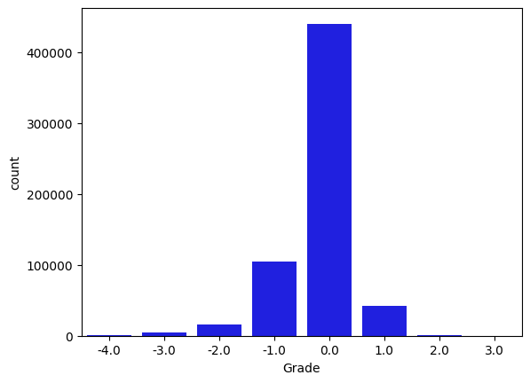

```python
sb.countplot(data=df_pisa, x='Grade', color='blue');
```

As we can see, there are no outliers as the data is tidy. The data seems normally distributed with the peak at 0.0 interval.

#### How is the Overall literacy of students?

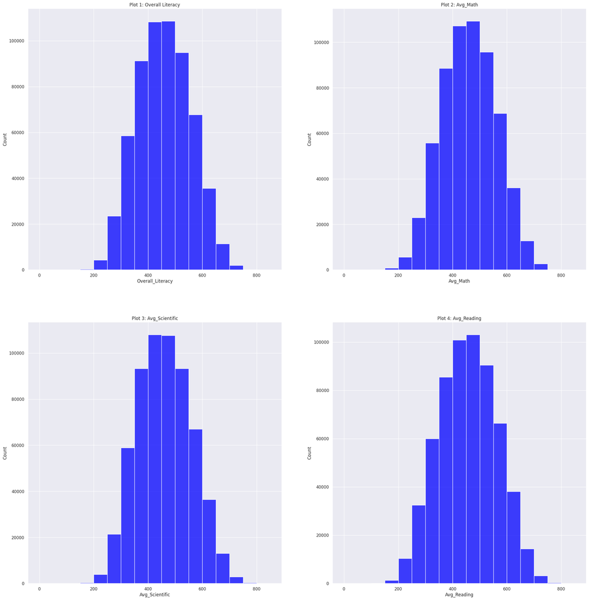

```python
fig, ax = plt.subplots(2,2, figsize=(27, 28))
bin_edges = np.arange(0,df_pisa.Overall_Literacy.max()+ 50,50)
sb.histplot(data=df_pisa, x='Overall_Literacy', bins= bin_edges, color='blue', ax=ax[0][0]);
ax[0][0].title.set_text('Plot 1: Overall Literacy')

bin_edges = np.arange(0,df_pisa.Avg_Math.max()+ 50,50)
sb.histplot(data=df_pisa, x='Avg_Math', bins= bin_edges, color='blue', ax=ax[0][1]);
ax[0][1].title.set_text('Plot 2: Avg_Math')

bin_edges = np.arange(0,df_pisa.Avg_Scientific.max()+ 50,50)
sb.histplot(data=df_pisa, x='Avg_Scientific', bins= bin_edges, color='blue', ax=ax[1][0]);
ax[1][0].title.set_text('Plot 3: Avg_Scientific')

bin_edges = np.arange(0,df_pisa.Avg_Reading.max()+ 50,50)
sb.histplot(data=df_pisa, x='Avg_Reading', bins= bin_edges, color='blue', ax=ax[1][1]);
ax[1][1].title.set_text('Plot 4: Avg_Reading')
```

In general, the average score is around 500 in all Maths, Science and reading.

#### How much time do students use computer?

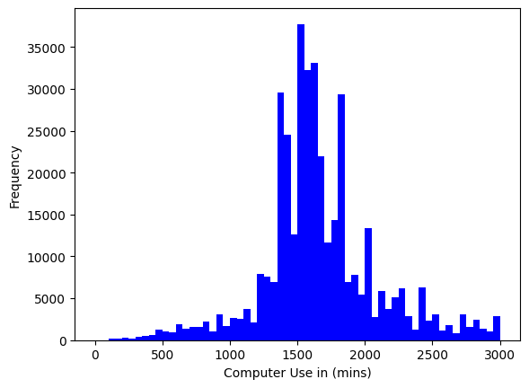

```python
bin_edges = np.arange(0,df_pisa.Computer_use_mins.max()+ 50,50)
plt.hist(data=df_pisa, x='Computer_use_mins', bins= bin_edges, color='blue');
plt.ylabel('Frequency');
plt.xlabel('Computer Use in (mins)');
```

In general, the time of using computer at home is around 1500 minutes.

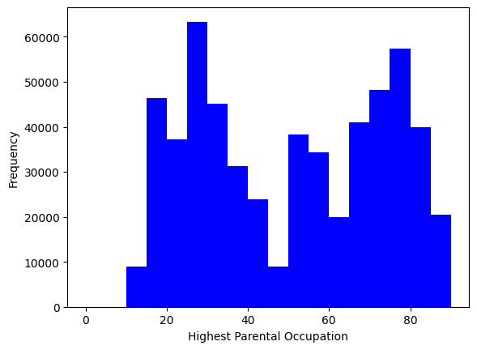

```python
bin_edges = np.arange(0,df_pisa.Highest_parental_occu_status.max() + 5, 5)
plt.hist(data=df_pisa, x='Highest_parental_occu_status', bins= bin_edges, color='blue');
plt.xlabel('Highest Parental Occupation');
plt.ylabel('Frequency');
```

It can be seen that, the data is almost evenly spread out with 2 peaks at 30 and 75.

## Bivariate Exploration

#### Top 10 Countries have the highest Overall Literacy

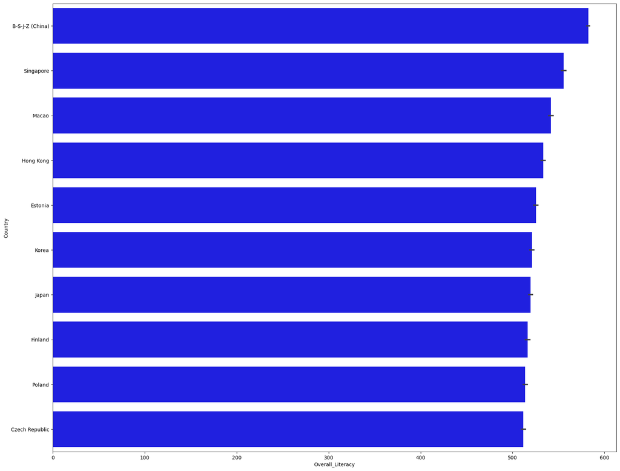

```python
plt.figure(figsize=(20,16))
result = df_pisa.groupby(["Country"])['Overall_Literacy'].aggregate(np.mean).reset_index().sort_values('Overall_Literacy', ascending= False)
sb.barplot(x='Overall_Literacy', y="Country", data=df_pisa, order=result['Country'].head(10), color='blue');
```

#### Relationship between Grade and Overall Literacy

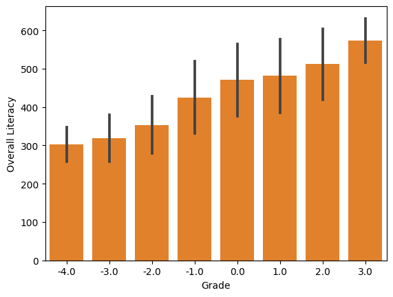

```python
base_color = sb.color_palette()[1]
sb.barplot(data=df_pisa, x='Grade', y='Overall_Literacy', color=base_color, ci='sd')
plt.xlabel('Grade');
plt.ylabel('Overall Literacy');
```

The variables Grade measured on a scale of -4.0 to 3.0 and Overall Literacy are analyzed. There is a strong positive correlation between the 2 factors. Scatter plot was not used as the plot of choice due to the discrete yet continuous nature of the Grade factor.

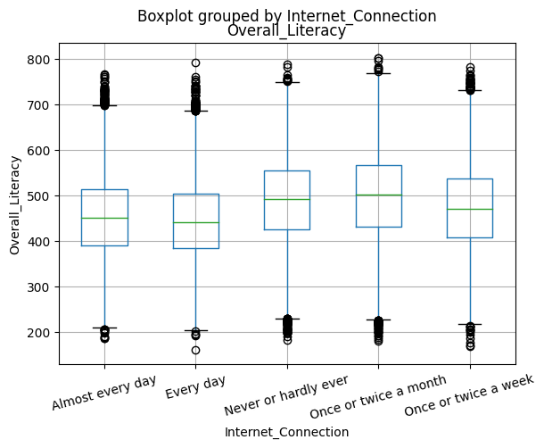

```python
df_pisa.boxplot(column = 'Overall_Literacy', by = 'Internet_Connection');
plt.xticks(rotation =15)
plt.xlabel('Internet_Connection')
plt.ylabel('Overall_Literacy')
plt.show()
```

We can see that, the Overall_Literacy is affected by the internet connection. The Overall_Literacy is highest at student group that they use once or twice a month and lowest at student group that they use everyday.

## Multivariate Exploration

#### Highest Parental Occupational Status vs Overall Literacy and Class Repeated

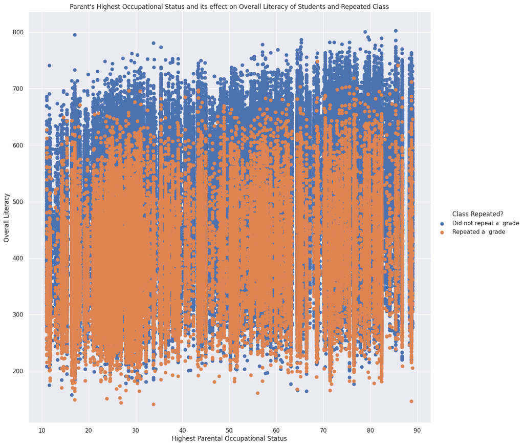

```python
g = sb.FacetGrid(data = df_pisa, hue = 'Class_repeated', height = 12)
g.map(plt.scatter, 'Highest_parental_occu_status', 'Overall_Literacy', alpha=1)
plt.title("Parent's Highest Occupational Status and its effect on Overall Literacy of Students and Repeated Class")
plt.xlabel('Highest Parental Occupational Status')
plt.ylabel('Overall Literacy')
g.add_legend(title ='Class Repeated?');
plt.rcParams.update({'font.size': 16});
```

As the Parents' occupational status increase so does the student's overall literacy, with that less and less students have repeated a class. The right side of the plot has majority of students who did not repeat a class whereas, as the parents' occupational status decrease so does the student's overall literacy, with that more and more students repeated a grade.

#### Highest Parental Occupational Status affects Overall Literacy and Grade

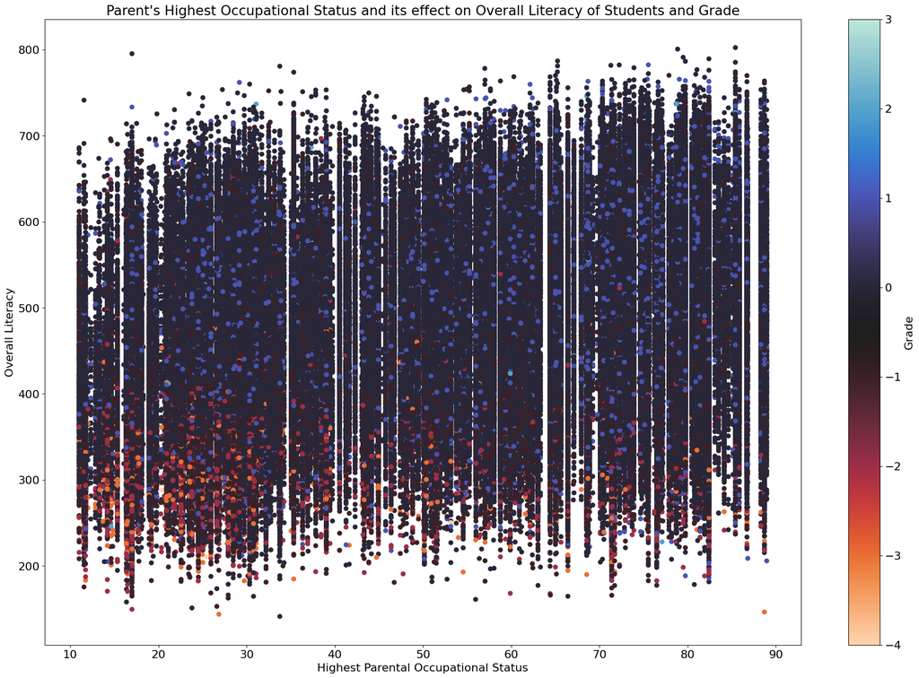

```python
plt.figure(figsize = [24, 16])
plt.scatter(data = df_pisa, x = 'Highest_parental_occu_status', y = 'Overall_Literacy', c = 'Grade',
            cmap = 'icefire_r', alpha=1)
plt.title("Parent's Highest Occupational Status and its effect on Overall Literacy of Students and Grade")
plt.xlabel('Highest Parental Occupational Status')
plt.ylabel('Overall Literacy')
plt.colorbar(label = 'Grade');
```

We can see that the student's overall literacy increase as the Parents' occupational status increase. The right side of the plot has majority of students who are in the country’s modal grade if not above the modal grade. Whereas, as the parents' occupational status decrease so does the student's overall literacy, with that more and more students are below the modal grade.

```python
df_pisa.Class_repeated.unique()
```

```
['Did not repeat a  grade', NaN, 'Repeated a  grade']
Categories (2, object): ['Did not repeat a  grade', 'Repeated a  grade']
```

#### Internet Connection affects Class Repeated and Overall Literacy

[figure not shown]

```python
g = sb.FacetGrid(data = df_pisa, col = 'Internet_Connection', col_wrap=2, height = 5)
g.map(sb.boxplot, 'Class_repeated', 'Overall_Literacy', color='darkred');
g.axes[0].set_title("No");
g.axes[1].set_title("Yes, but I don't use it");
g.axes[2].set_title("Yes, and I use it");
g.axes[3].set_title("Once or twice a month");
g.axes[4].set_title("Once or twice a week");
```

## Conclusions

> After explorating the dataset, I find some key points as follows:
> 1. For the Grade Distribution

The data seems normally distributed with the peak at 0.0 interval and there are no outliers as the data is tidy.

> 2. For the Overall literacy

The average score is around 500 in all Maths, Science and reading.

> 4. Relationship between Internet connection and Overall Literacy

The Overall_Literacy is affected by the internet connection. The Overall_Literacy is highest at student group that they use once or twice a month and lowest at student group that they use everyday.

> 5. Highest Parental Occupational Status affect Overall Literacy and Class Repeated

As the Parents' occupational status increase so does the student's overall literacy, with that less and less students have repeated a class. The right side of the plot has majority of students who did not repeat a class whereas, as the parents' occupational status decrease so does the student's overall literacy, with that more and more students repeated a grade.